# R Notebook

# COVID PHU-Level Clustering

## Hierarchical Clustering Methods

### Agglomerative Clustering:

Data is first scaled then the euclidean distance is computed between each PHU. Clusters are formed based on least dissimilarities between observations.

*Group average clustering:* attempts to produce relatively compact that are relatively far apart.

*Complete clustering:* all union observations for two groups are least dissimilar - can produce clusters that violate “closeness” property (one observation may be more similar to observations in other groups).

*Single clustering:* grouped based on one dissimilarity measure common between two observations being very small - prone to chaining.

Using 2 clusters…

| cluster | n |
| --- | --- |
| 1 | 29 |
| 2 | 5 |

The agglomerative coefficient for complete linkage:

```
## [1] "Agglomerative Coefficient:  0.662886972317548"
```

### Divisive Hierarchical Clustering - DIANA

All observations begin as a single cluster and are divisible separated based on largest average dissimilarity between an observation and all others.

Hierarchical clustering will always cluster even if there is no grouping in the data. The divisive coefficient is on a 0-1 scale, representing the extent to which the hierarchical structure produced by a dendrogram actually represents the data (closer to 1 = better representation).

```
## [1] "Divisive Coefficient:  0.652378950559646"
```

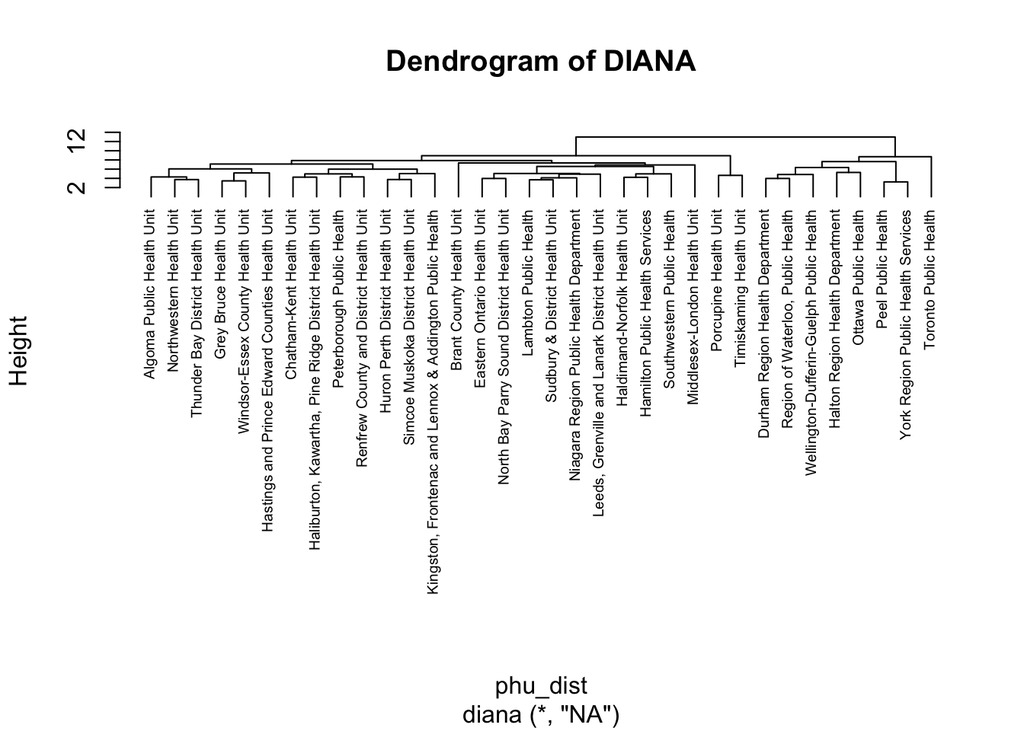

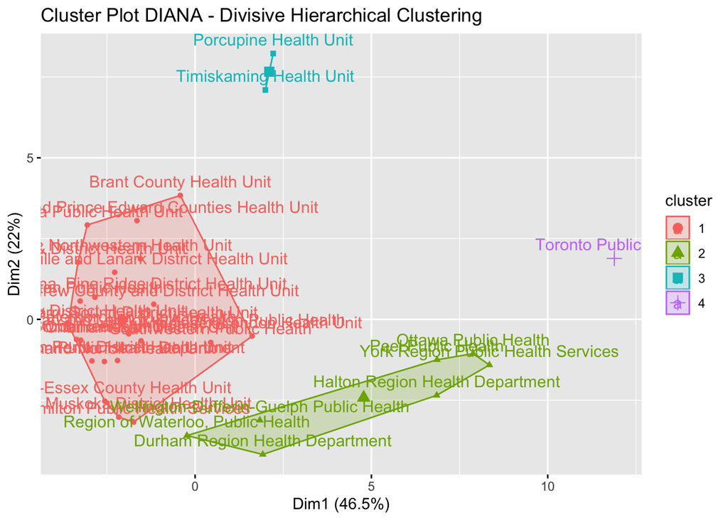

Covid Case Total Proportions (per PHU) data and DIANA cluster assignment are added to `phu_prop` to assess groupings by covid output.

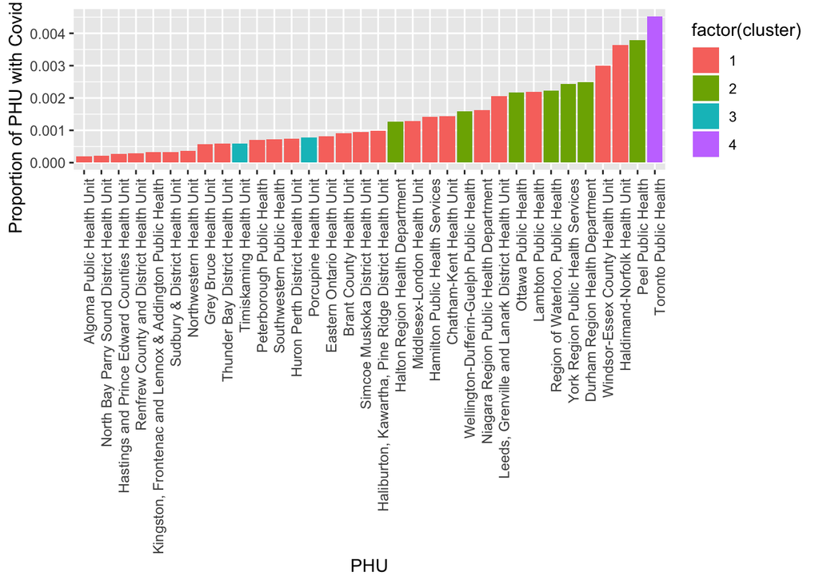

## Mixture Model Clustering Methods

### EM Algorithm

Soft version of K-means clustering that is based on probabilities rather than deterministic assignments of points to groups. Used package `Mclust`.

```r
# EM view clasess ----
classes <- mutate(as.data.frame(mcovid$classification), loc = phu$Location_x)
colnames(classes)[1] <- 'class'
classes <- classes[order(classes),]
classes
```

|  | class | loc |
| --- | --- | --- |
| 1 | 1 | Algoma Public Health Unit |
| 2 | 1 | Brant County Health Unit |
| 5 | 1 | Eastern Ontario Health Unit |
| 6 | 1 | Grey Bruce Health Unit |
| 8 | 1 | Haliburton, Kawartha, Pine Ridge District Health Unit |
| 11 | 1 | Hastings and Prince Edward Counties Health Unit |
| 12 | 1 | Huron Perth District Health Unit |
| 17 | 1 | North Bay Parry Sound District Health Unit |
| 18 | 1 | Northwestern Health Unit |
| 21 | 1 | Peterborough Public Health |

[output cut: 58 more lines]

### Multidimensional Scaling

Uses euclidean distances of scaled PHU data. Similarly represents hierarchical clustering (Toronto is its own cluster, denser regions such as Peel, Halton, York, Waterloo, Ottawa…etc. separate from smaller districts).

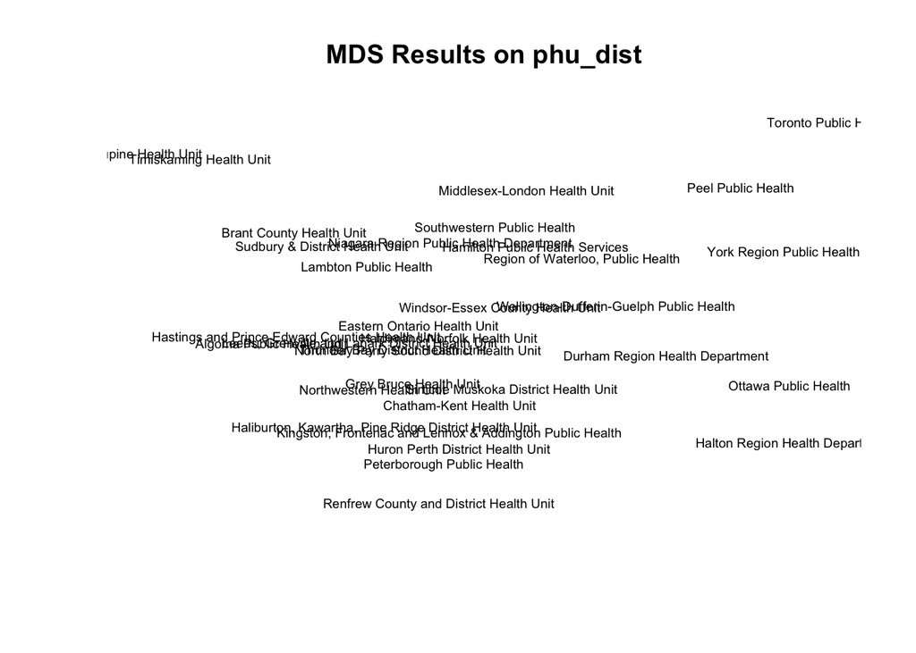

```r
plot(cmdscale(phu_dist)[,1], cmdscale(phu_dist)[,2], type = "n",
     xlab = "", ylab = "",
     asp = 1, axes = FALSE,
     main = "MDS Results on phu_dist")
text(cmdscale(phu_dist)[,1], cmdscale(phu_dist)[,2], rownames(cmdscale(phu_dist)), cex = 0.6)
```